# E-Commerce_Project_Final_Student_File

Capstone Project

Name: Panagam Mohitha

**Problem Statement** Sales Analytics

**Context:** You have been given the role of a business analyst for an E-Commerce company and have been asked to prepare a basic report on the data. Follow the steps below for preparation of the report.

Before you start analysing the data, it is always a good practice to see the size of the data, its features and feature types. If the data set is big, it is not possible to print out all the records.

## Load the necessary libraries. Import and load the dataset with a name ECom_Data .

```python
import numpy as np
import pandas as pd
import matplotlib.pyplot as plt
import seaborn as sns; sns.set()
pd.options.display.max_rows = 10
import warnings
import os
import re
import copy
```

```python
# suppress display of warnings
warnings.filterwarnings('ignore')

# display all dataframe columns
pd.options.display.max_columns = None

# to set the limit to 3 decimals
pd.options.display.float_format = '{:.3f}'.format

# display all dataframe rows
pd.options.display.max_rows = None
```

```python
# Get the Data

ECom_Data=pd.read_csv('C:\\Users\\Mohitha Panagam\\Downloads\\Capstone_Project\\E-Commerce_Flipkart.csv')
```

We have read the data and stored the data in "ECom_Data" variable

## Q 1. To get familiar with the data

## a) Print out the first 10 and the last 10 records of the data. (2 marks)

## b) How many rows and columns are present in the dataset? Use any two different methods to extract this information. (2 + 2 + 1 marks)

## c) How many object data types are there? (1 mark)

## d) Is there any Boolean data type? (1 mark)

#### Note: Use the markdown feature of Python to explain your answer.

#### Ans 1 a)

```python
ECom_Data.head(10)
```

|  | Customer_uniq_id | Region | Order_Date | Expected_Delivery_Date | Delivered_Date | product_name | product_main_category | product_subcategory | product_category_filter | product_category_subfilter | product_unique ID | retail_price | discounted_price | product_rating | Brand |
| --- | --- | --- | --- | --- | --- | --- | --- | --- | --- | --- | --- | --- | --- | --- | --- |
| 0 | c2d766ca982eca8304150849735ffef9 | North | 31-12-2021 | 03-01-2022 | 02-01-2022 | Alisha Solid Women's Cycling Shorts | Clothing | Women's Clothing | Lingerie, Sleep & Swimwear | Shorts | SRTEH2FF9KEDEFGF | 999 | 379 | 2.000 | Alisha |
| 1 | 7f7036a6d550aaa89d34c77bd39a5e48 | East | 31-12-2021 | 03-01-2022 | 02-01-2022 | FabHomeDecor Fabric Double Sofa Bed | Furniture | Living Room Furniture | Sofa Beds & Futons | FabHomeDecor Fabric Double Sofa Bed (Finish C... | SBEEH3QGU7MFYJFY | 32157 | 22646 | 2.000 | FabHomeDecor |
| 2 | f449ec65dcbc041b6ae5e6a32717d01b | East | 31-12-2021 | 03-01-2022 | 02-01-2022 | AW Bellies | Footwear | Women's Footwear | Ballerinas | AW Bellies | SHOEH4GRSUBJGZXE | 999 | 499 | 1.000 | AW |
| 3 | 0973b37acd0c664e3de26e97e5571454 | West | 31-12-2021 | 03-01-2022 | 02-01-2022 | Alisha Solid Women's Cycling Shorts | Clothing | Women's Clothing | Lingerie, Sleep & Swimwear | Shorts | SRTEH2F6HUZMQ6SJ | 699 | 267 | 5.000 | Alisha |
| 4 | bc940ea42ee6bef5ac7cea3fb5cfbee7 | West | 31-12-2021 | 03-01-2022 | 02-01-2022 | Sicons All Purpose Arnica Dog Shampoo | Pet Supplies | Grooming | Skin & Coat Care | Shampoo | PSOEH3ZYDMSYARJ5 | 220 | 210 | 5.000 | Sicons |
| 5 | ce5a6818f7707e2cb61fdcdbba61f5ad | East | 25-12-2021 | 28-12-2021 | 27-12-2021 | Alisha Solid Women's Cycling Shorts | Clothing | Women's Clothing | Lingerie, Sleep & Swimwear | Shorts | SRTEH2FVVKRBAXHB | 1199 | 479 | 4.000 | Alisha |
| 6 | 8542703ca9e6ebdf6d742638dfb1f2ca | East | 25-12-2021 | 28-12-2021 | 27-12-2021 | FabHomeDecor Fabric Double Sofa Bed | Furniture | Living Room Furniture | Sofa Beds & Futons | FabHomeDecor Fabric Double Sofa Bed (Finish C... | SBEEH3QGYGHFUEXN | 32157 | 22646 | 2.000 | FabHomeDecor |
| 7 | 29c8d290caa451f97b1c32df64477a2c | North | 25-12-2021 | 28-12-2021 | 27-12-2021 | dilli bazaaar Bellies, Corporate Casuals, Casuals | Footwear | Women's Footwear | Ballerinas | dilli bazaaar Bellies, Corporate Casuals, Cas... | SHOEH3DZBFR88SCK | 699 | 349 | 5.000 | dilli bazaaar |
| 8 | 4044c0ac52c1ee4b28777417651faf42 | East | 25-12-2021 | 28-12-2021 | 27-12-2021 | Alisha Solid Women's Cycling Shorts | Clothing | Women's Clothing | Lingerie, Sleep & Swimwear | Shorts | SRTEH2FVUHAAVH9X | 1199 | 479 | 1.000 | Alisha |
| 9 | e54bc0a7c3429da2ebef0b30331fe3d2 | East | 25-12-2021 | 28-12-2021 | 27-12-2021 | Ladela Bellies | Footwear | Women's Footwear | Ballerinas | Ladela Bellies | SHOEH4KM2W3Z6EH5 | 1724 | 950 | 5.000 | Ladela |

```python
ECom_Data.tail(10)
```

|  | Customer_uniq_id | Region | Order_Date | Expected_Delivery_Date | Delivered_Date | product_name | product_main_category | product_subcategory | product_category_filter | product_category_subfilter | product_unique ID | retail_price | discounted_price | product_rating | Brand |
| --- | --- | --- | --- | --- | --- | --- | --- | --- | --- | --- | --- | --- | --- | --- | --- |
| 8917 | 4db03bc4ccbe216cf151b2f2b904ba3f | East | 01-12-2020 | 04-12-2020 | 04-12-2020 | Luca Fashion Girls Heels | Footwear | Kids' & Infant Footwear | For Girls | Sandals | SNDEHG3DNVBFGAT5 | 999 | 499 | 4.000 | Luca Fashion |
| 8918 | 4d4d6aeb13fa253499d0dd45a5abd87e | West | 01-12-2020 | 04-12-2020 | 04-12-2020 | Shoetopia Girls Sandals | Footwear | Kids' & Infant Footwear | For Girls | Sandals | SNDEG7DRWSX8HFXZ | 499 | 399 | 4.000 | Shoetopia |
| 8919 | ea19e7ef703293d3f6c799ca9db4642d | West | 01-12-2020 | 04-12-2020 | 04-12-2020 | SMART TRADERS Girls Sandals | Footwear | Kids' & Infant Footwear | For Girls | Sandals | SNDEG7MZHHKZ58D2 | 999 | 499 | 5.000 | SMART TRADERS |
| 8920 | 19a53a958992fb575acffb5d41e7ef9e | East | 01-12-2020 | 04-12-2020 | 04-12-2020 | Beanz Girls Flats | Footwear | Kids' & Infant Footwear | For Girls | Sandals | SNDEG7DYVFWHZBC4 | 1299 | 1299 | 3.000 | Beanz |
| 8921 | 09abab80c8dfdc6f268e0a6f05a0be11 | North | 01-12-2020 | 04-12-2020 | 04-12-2020 | Nova KT 728S Electric Kettle | Home & Kitchen | Kitchen Appliances | Electric Jug(heater)/Travel Kettles | Nova Electric Jug(heater)/Travel Kettles | EKTDG5C5QSADZZ8J | 3195 | 699 | 3.600 | Nova |
| 8922 | 90d30478255e23621e8929ed15c2f6e4 | South | 01-12-2020 | 04-12-2020 | 04-12-2020 | Sinina Chanderi Embroidered Salwar Suit Dupatt... | Clothing | Women's Clothing | Ethnic Wear | Fabric | FABEGGHHDFMY8BZU | 2980 | 1490 | 3.000 | Sinina |
| 8923 | 20a73e3f41490a73ceeba5f17658db8f | West | 01-12-2020 | 04-12-2020 | 04-12-2020 | Aarushi Fashion Chanderi Embroidered Salwar Su... | Clothing | Women's Clothing | Ethnic Wear | Fabric | FABEG8GFDUWRSNU3 | 2600 | 1300 | 1.000 | Aarushi Fashion |
| 8924 | 5c1554cd45f9d538c2c6947dbdd59c75 | East | 01-12-2020 | 04-12-2020 | 04-12-2020 | Ambika Lahenga Embroidered Lehenga, Choli and ... | Clothing | Women's Clothing | Ethnic Wear | Lehenga Cholis | LEHEGGEHYN4G2RPW | 39992 | 24995 | 1.000 | Ambika Lahenga |
| 8925 | 6b737a4deca1ed0e56c179e66036e994 | West | 01-12-2020 | 04-12-2020 | 04-12-2020 | Sinina Chanderi Embroidered Salwar Suit Dupatt... | Clothing | Women's Clothing | Ethnic Wear | Fabric | FABEGGHHGSVCHGFV | 2000 | 1000 | 3.000 | Sinina |
| 8926 | a5235ac28d3d5487f54025f9d6b57433 | North | 01-12-2020 | 04-12-2020 | 04-12-2020 | Aarushi Fashion Silk Striped Salwar Suit Dupat... | Clothing | Women's Clothing | Ethnic Wear | Fabric | FABEG8GYDAABECZH | 2800 | 1350 | 4.000 | Aarushi Fashion |

#### Ans 1 b)

```python
# Method 1
print("Number of Rows:", ECom_Data.shape[0])
print("Number of Columns:", ECom_Data.shape[1])
```

```
Number of Rows: 8927
Number of Columns: 17
```

```python
# Method 2
print("Number of Rows: " + str(len(ECom_Data.axes[0])))
print("Number of Columns: " + str(len(ECom_Data.axes[1])))
```

```
Number of Rows: 8927
Number of Columns: 17
```

```python
# Method 3
ECom_Data.info(verbose = False)
```

```
<class 'pandas.core.frame.DataFrame'>
RangeIndex: 8927 entries, 0 to 8926
Columns: 17 entries, Customer_uniq_id to description
dtypes: float64(1), int64(2), object(14)
memory usage: 1.2+ MB
```

#### Ans 1 c)

```python
try:
    is_object = ECom_Data.dtypes.value_counts()['object']
    print('Count of object data types: ', is_object)
except:
    print('No object type data')
```

[output not shown]

### Ans 1 d)

```python
try:
    is_bool = ECom_Data.dtypes.value_counts()['boolean']
    print('Count of object data types: ', is_bool)
except:
    print('No boolean type data')
```

```
No boolean type data
```

**Inference:**

Once you are familiar with the data, you may decide that not all features are of use to you and you may want to delete the non-informative features (columns)

## Q 2. Eliminating the non-informative columns.

## a) Drop the columns product_specifications and description. (2 marks)

## b) Which method or function is used to permanently delete the columns mentioned in part (b)? Write the code explicitly (2 marks)

### Note: Use the markdown feature of Python to explain your answer.

### Ans 2 a)

```python
ECom_Data.drop(columns=['product_specifications','description']).head(1)
```

|  | Customer_uniq_id | Region | Order_Date | Expected_Delivery_Date | Delivered_Date | product_name | product_main_category | product_subcategory | product_category_filter | product_category_subfilter | product_unique ID | retail_price | discounted_price | product_rating | Brand |
| --- | --- | --- | --- | --- | --- | --- | --- | --- | --- | --- | --- | --- | --- | --- | --- |
| 0 | c2d766ca982eca8304150849735ffef9 | North | 31-12-2021 | 03-01-2022 | 02-01-2022 | Alisha Solid Women's Cycling Shorts | Clothing | Women's Clothing | Lingerie, Sleep & Swimwear | Shorts | SRTEH2FF9KEDEFGF | 999 | 379 | 2.000 | Alisha |

### Ans 2 b)

```python
ECom_Data = ECom_Data.drop(columns=['product_specifications','description'])
```

**Inference:**

- Drop function is used to permanently delete the columns from the dataframe.

The next steps in this project involves summarization of data at various levels and visualization. Such apparently simple steps are very useful to get an overall sense of the data.

## Q 3. Here we summarize the data at brand level.

## a) How many unique Brands are there. (1 mark)

## b) Note that each brand contains multiple products. Show the average rating of the products within each Brand (2 marks)

### Ans 3 a)

```python
print('Number of unique Brands:', len(ECom_Data['Brand'].unique()))
```

```
Number of unique Brands: 2580
```

### Ans 3 b)

```python
ECom_Data.groupby(['Brand'])['product_rating'].mean().reset_index()
```

|  | Brand | product_rating |
| --- | --- | --- |
| 0 | 1OAK | 1.500 |
| 1 | 3A AUTOCARE | 3.268 |
| 2 | 3D Mat | 3.000 |
| 3 | 3kFactory | 2.000 |
| 4 | 4D | 3.600 |
| 5 | 4D Mats | 4.333 |
| 6 | 5 FEELINGS | 4.000 |
| 7 | 69th Avenue | 2.000 |
| 8 | 720 Armour | 2.500 |
| 9 | 99Gems | 2.500 |
| 10 | @home | 3.250 |
| 11 | A A STORE | 4.750 |
| 12 | A R ENTERPRISES | 4.000 |
| 13 | A To Z Traders | 1.000 |
| 14 | A-maze | 3.000 |
| 15 | ABIDA | 5.000 |
| 16 | ABSTAR | 5.000 |
| 17 | ACCESSOREEZ | 4.000 |
| 18 | ACM | 3.400 |
| 19 | ADDICTION | 1.333 |
| 20 | ADIWALK | 2.000 |
| 21 | AHAANA FASHION | 3.000 |
| 22 | AJ Dezines | 3.300 |
| 23 | AKUP | 2.591 |
| 24 | ALIFS | 5.000 |
| 25 | ALL DAY 365 | 2.333 |
| 26 | AM Creation | 5.000 |
| 27 | AMCO | 2.000 |
| 28 | AMZER | 4.333 |
| 29 | ANAHI | 2.500 |

[output cut: 2550 more lines]

**Inference:**

- ECom_Data['Brand'].unique() returns the length of the array of unique values of the brand
- groupby() returns the data group by brand and mean() gives the calculated average ratings of the products for each brand

## Q 4. Next we study the main categories of the products.

## a) Create an appropriate plot to show the count of items ordered for each product_main_category. (5 marks).

### Hint: Create a bar chart titled "Product Category type" where product names are on x-axis and counts are on y-axis.

### Note: Both axis labels, i.e. the names of the product categories and counts must be clearly legible.

## b) From the plot identify for which two product_main_category(s) the maximum and the minimum orders were placed. (2 marks)

## c) Write code to print out the top 5 product_main_category(s) in descending order? (2 marks)

### Ans 4 a)

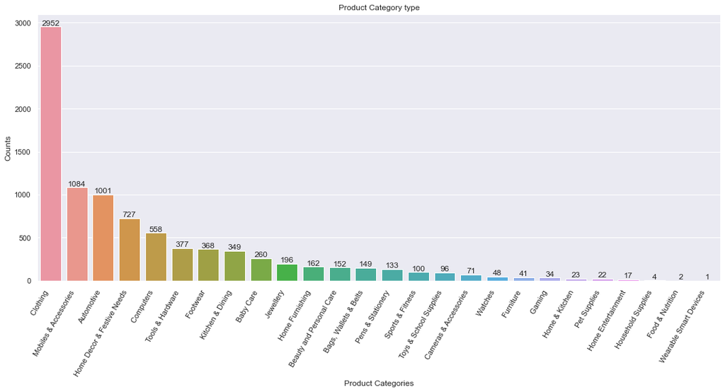

```python
plt.figure(figsize=(15,8))
cp = sns.countplot(x ='product_main_category', data = ECom_Data, order = ECom_Data['product_main_category'].value_counts().index)
cp.set_xticklabels(cp.get_xticklabels(), rotation=60, ha="right")
cp.bar_label(cp.containers[0])
plt.tight_layout()
plt.xlabel("Product Categories")
plt.ylabel("Counts")
plt.title("Product Category type")
plt.show()
```

### Ans 4 b)

From the above graph,

- clothing has the maximum number of orders placed and
- Wearables Smart Devices have the minimum orders were placed

### Ans 4 c)

```python
Product_category_sort = ECom_Data.groupby(['product_main_category'])['Customer_uniq_id']\
.count().reset_index().sort_values(by=['Customer_uniq_id'], ascending=False).rename({'Customer_uniq_id':'orders'},axis=1)
```

```python
Product_category_sort.head(5)
```

|  | product_main_category | orders |
| --- | --- | --- |
| 5 | Clothing | 2952 |
| 18 | Mobiles & Accessories | 1084 |
| 0 | Automotive | 1001 |
| 12 | Home Decor & Festive Needs | 727 |
| 6 | Computers | 558 |

In E-commerce, both the retailers (here brands) and the company have to make profit to sustain in the business. The E-Commerce company has the following rule for computing their own revenue, which depends on how much each retailer can sell.

#### The company charges each retailer (Brand)

#### (i) 25% on the final price (discounted price) of total orders if the number of orders placed is greater than 600

#### (ii) 15% on the final price (discounted price) of total orders if the number of orders placed is greater than 350 but less than or equal to 600

#### (iii) 10% on the final price (discounted price) of total orders if the number of orders placed is greater than 100 but less than or equal to 350

#### (iv) Otherwise, 5% on the final price (discounted price) of total orders

## Q 5. Find the net revenue generated by the E-Commerce company over all orders placed. (6 marks)

### Ans 5

```python
def total_payment(retailer_sale):
    if retailer_sale.orders > 600:
        Ecom_charges = retailer_sale.discounted_price *0.25
    elif retailer_sale.orders > 350 and retailer_sale.orders <= 600 :
        Ecom_charges = retailer_sale.discounted_price *0.15
    elif retailer_sale.orders > 100 and retailer_sale.orders <= 350 :
        Ecom_charges = retailer_sale.discounted_price *0.10
    else:
         Ecom_charges = retailer_sale.discounted_price *0.05
    return Ecom_charges
```

```python
net_revenue = ECom_Data.groupby(['Brand']).agg({'Customer_uniq_id':'count','discounted_price':'sum'}).reset_index()\
                                .rename({'Customer_uniq_id':'orders'},axis=1)
net_revenue['Ecom_charges'] = net_revenue.apply(total_payment, axis = 1)
print('Total revenue of E-commerce company', round(net_revenue['Ecom_charges'].sum(),2))
```

```
Total revenue of E-commerce company 615446.95
```

Now you need to find the revenue for each retailer (Brand)

## Q6.Calculate the BrandRevenue for each brand and list the top 14 brands having maximum revenue in descending order (5 marks)

#### Hint: Brand revenue is different from the E-Commerce company revenue.

### Ans 6

```python
net_revenue['brand_profit'] = net_revenue['discounted_price'] - net_revenue['Ecom_charges']
net_revenue_brand = net_revenue[['Brand','brand_profit']]
net_revenue_brand.sort_values(by=['brand_profit'],ascending=False).reset_index(drop=True).head(14)
```

|  | Brand | brand_profit |
| --- | --- | --- |
| 0 | Allure Auto | 564926.150 |
| 1 | GAGA | 300694.000 |
| 2 | Slim | 244959.300 |
| 3 | DailyObjects | 218376.000 |
| 4 | Diviniti | 181279.000 |
| 5 | Enthopia | 147775.500 |
| 6 | Regular | 137232.000 |
| 7 | Asus | 125705.900 |
| 8 | TheLostPuppy | 123453.900 |
| 9 | Springwel | 112706.100 |
| 10 | Audeze | 110477.400 |
| 11 | Lal Haveli | 93802.050 |
| 12 | FabHomeDecor | 86054.800 |
| 13 | Netgear | 83484.100 |

Let us now investigate multiple features for each product to determine any pattern.

## Q 7. Compare prices for each product.

## a) Draw boxplots of retail_price & discount_price. (2 marks)

## b) Are there any outliers? (Yes/No) (1mark)

## c) Create a scatterplot of retail_price (x-axis) and discounted_price (y-axis) (2 marks)

```python
ECom_Data.head(1)
```

|  | Customer_uniq_id | Region | Order_Date | Expected_Delivery_Date | Delivered_Date | product_name | product_main_category | product_subcategory | product_category_filter | product_category_subfilter | product_unique ID | retail_price | discounted_price | product_rating | Brand |
| --- | --- | --- | --- | --- | --- | --- | --- | --- | --- | --- | --- | --- | --- | --- | --- |
| 0 | c2d766ca982eca8304150849735ffef9 | North | 31-12-2021 | 03-01-2022 | 02-01-2022 | Alisha Solid Women's Cycling Shorts | Clothing | Women's Clothing | Lingerie, Sleep & Swimwear | Shorts | SRTEH2FF9KEDEFGF | 999 | 379 | 2.000 | Alisha |

### Ans 7 a)

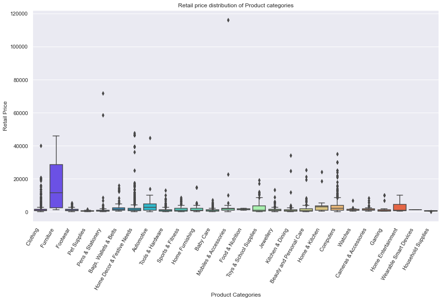

```python
plt.figure(figsize=(15,8))
bp = sns.boxplot(x='product_main_category',y='retail_price',data=ECom_Data, palette='rainbow')
bp.set_xticklabels(bp.get_xticklabels(), rotation=60, ha="right")
plt.xlabel("Product Categories")
plt.ylabel("Retail Price")
plt.title("Retail price distribution of Product categories")
plt.show()
```

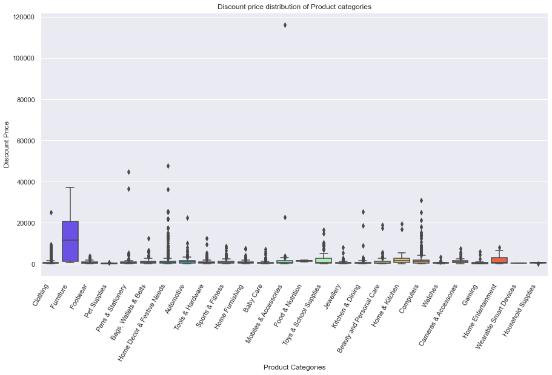

```python
plt.figure(figsize=(15,8))
bp = sns.boxplot(x='product_main_category',y='discounted_price',data=ECom_Data, palette='rainbow')
bp.set_xticklabels(bp.get_xticklabels(), rotation=60, ha="right")
plt.xlabel("Product Categories")
plt.ylabel("Discount Price")
plt.title("Discount price distribution of Product categories")
plt.show()
```

### Ans 7 b)

Yes, as per the above charts, it is clear that both the Retail price and Discounted price have outliers.

### Ans 7 c)

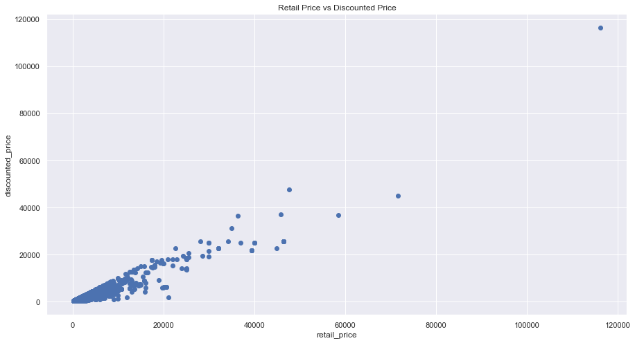

```python
plt.figure(figsize=(15,8))
plt.scatter(ECom_Data['retail_price'], ECom_Data['discounted_price'])
plt.title("Retail Price vs Discounted Price")
plt.xlabel("retail_price")
plt.ylabel("discounted_price")
plt.show()
```

The next steps will enable to study brand-level information. </font>

## Q 8. Create a new dataframe to include the brand specific information as stated:

## i. total number of orders placed per brand

## ii. total retail_price per brand

## iii. total discount_price per brand, and

## iv. total BrandRevenue generated per brand.

## Also, draw a pairplot using these four features. (3 marks)

### Ans 8

```python
net_revenue_brand_info = ECom_Data.groupby(['Brand']).agg({'Customer_uniq_id':'count','retail_price':'sum','discounted_price':'sum'}).reset_index()\
                                .rename({'Customer_uniq_id':'orders'},axis=1)
net_revenue_brand_info['Ecom_charges'] = net_revenue_brand_info.apply(total_payment, axis = 1)
net_revenue_brand_info['BrandRevenue'] = net_revenue_brand_info['discounted_price'] - net_revenue['Ecom_charges']
net_revenue_brand_info = net_revenue_brand_info[['Brand','orders','retail_price','discounted_price','BrandRevenue']]
```

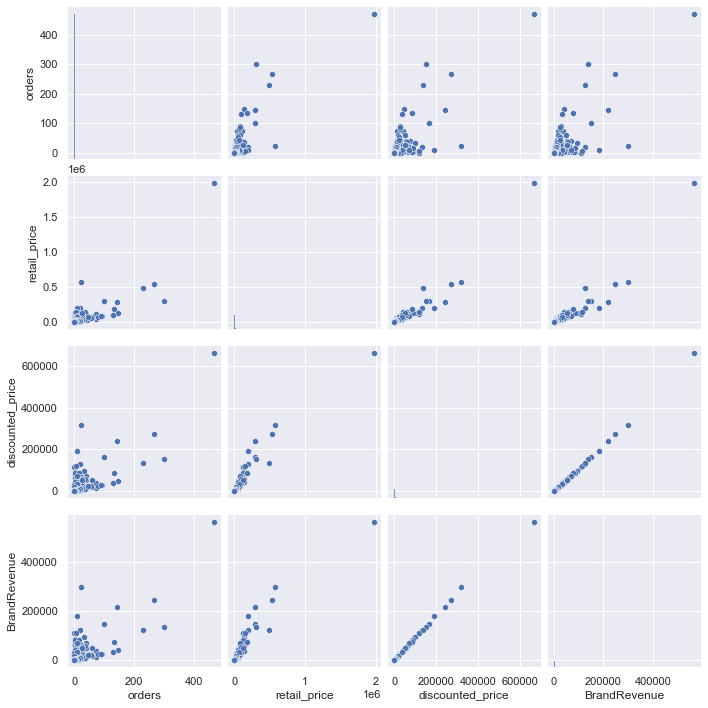

```python
sns.pairplot(net_revenue_brand_info[['orders','retail_price','discounted_price','BrandRevenue']])
```

The E-Commerce company operate in multiple regions. It is important to understand its performance in each region.

## Q 9.Compare performance regionwise

## a) Draw a lineplot for the monthly Revenue of ECom Company for each region separately. (4 marks)

## b) Identify the best and the worst performing months for each region. (2 marks)

### Ans 9 a)

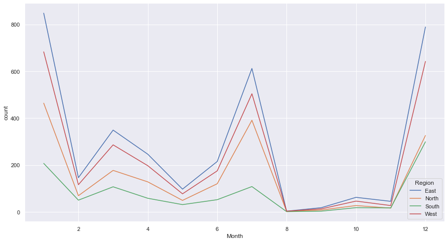

```python
data_region = copy.deepcopy(ECom_Data)
data_region['Month'] = pd.to_datetime(data_region['Order_Date']).dt.month
data_region = data_region.groupby(['Month','Region'])['Order_Date'].count().reset_index().rename({'Order_Date':'count'},axis=1)
plt.figure(figsize=(15,8))
sns.lineplot(data = data_region, x = 'Month', y = 'count', hue = 'Region')
plt.show()
```

### Ans 9 b)

January is the best performing month for all except South region. August is worst performing month for all regions. Whereas South region records December as it's best performing month

Congratulations! You have learnt how to approach a complex data and extract information out of it.